# IODS course project

### Linear discriminant analysis

With the data in order, we can now fit a linear discriminant analysis on our newly created train set and plot it:

```r
lda.fit <- lda(crime ~ ., data = train)
lda.fit
```

```
## Call:
## lda(crime ~ ., data = train)
##
## Prior probabilities of groups:
##      low  med_low med_high     high
## 0.259901 0.250000 0.240099 0.250000
##
## Group means:
##                  zn      indus          chas        nox          rm        age
## low       0.8950370 -0.8760507 -0.1223442968 -0.8493424  0.41381867 -0.8311136
## med_low  -0.1569589 -0.2709855  0.0005392655 -0.5340474 -0.11542521 -0.2719506
## med_high -0.3891090  0.1203275  0.2147348790  0.3926625  0.04858807  0.3933193
## high     -0.4872402  1.0171306 -0.0384419250  1.0403425 -0.42886437  0.7916311
##                 dis        rad        tax     ptratio      black        lstat
## low       0.7952599 -0.6909262 -0.7520119 -0.36086261  0.3830077 -0.748376987
## med_low   0.2854839 -0.5520489 -0.5124442 -0.06269516  0.3330827 -0.138523083
## med_high -0.3670375 -0.3827740 -0.3097610 -0.23374679  0.1094210 -0.008628961
## high     -0.8560467  1.6379981  1.5139626  0.78062517 -0.6893469  0.867304028
##                 medv
## low       0.49824724
## med_low   0.02549938
## med_high  0.11222469
## high     -0.65551568
##
## Coefficients of linear discriminants:
##                  LD1         LD2         LD3
## zn       0.075977373  0.83439842 -0.87087364
## indus   -0.000634016 -0.13407752  0.40767247
## chas    -0.058154413 -0.13525497  0.03159846
## nox      0.389244101 -0.63107633 -1.52205671
## rm      -0.087973105 -0.03833535 -0.15713978
## age      0.283660034 -0.30530130 -0.05989929
## dis     -0.066158334 -0.28949969  0.21719689
## rad      2.934404238  1.02723854  0.04020048
## tax      0.038416490 -0.22563501  0.50454150
## ptratio  0.121630680  0.08114678 -0.32491816
## black   -0.128333771  0.00137541  0.13484090
## lstat    0.198701266 -0.20524328  0.41754016
## medv     0.155999780 -0.25920858 -0.12376960
##
## Proportion of trace:
##    LD1    LD2    LD3
## 0.9483 0.0376 0.0141
```

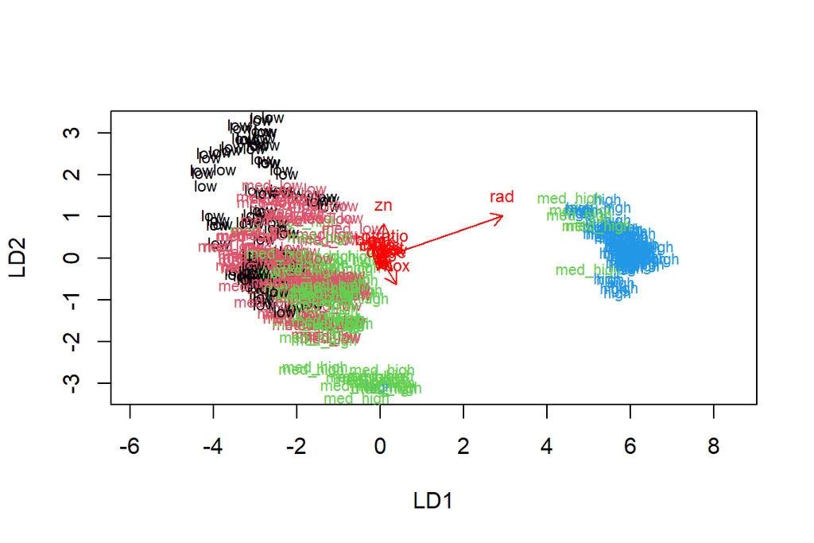

```r
lda.arrows <- function(x, myscale = 1, arrow_heads = 0.1, color = "red", tex = 0.75, choices = c(1,2)){
  heads <- coef(x)
  arrows(x0 = 0, y0 = 0,
         x1 = myscale * heads[,choices[1]],
         y1 = myscale * heads[,choices[2]], col=color, length = arrow_heads)
  text(myscale * heads[,choices], labels = row.names(heads),
       cex = tex, col=color, pos=3)
}

classes <- as.numeric(train$crime)
plot(lda.fit, dimen = 2, col = classes, pch = classes)
lda.arrows(lda.fit, myscale = 1)
```

From the relative length of the arrows in the plot it is apparent that the variable rad has by far the largest impact on the class grouping. From the “proportion of trace” listing we also see that the LD1 discriminant (represented by the x-axis in the plot) explains about 95% of the variance between the groups.

We can now use our linear discriminant analysis fit to predict the crime classes on the test data. Since we know the correct classes, we can compare the results to see how accurate our prediction is:

```r
correct_classes <- test$crime
test <- dplyr::select(test, -crime)
lda.pred <- predict(lda.fit, newdata = test)
table(correct = correct_classes, predicted = lda.pred$class)
```

```
##           predicted
## correct    low med_low med_high high
##   low       13       9        0    0
##   med_low    7      16        2    0
##   med_high   1       5       23    0
##   high       0       0        0   26
```

The predictions of our LDA model appear to be very good for the “high” class and passable for the “med_low” and “low” classes on average. For the “med_high” class, our model sometimes seems to have trouble separating between “med_high” and “med_low”. In conclusion, our model can accurately predict whether the crime rate of the suburb is in the “high” category.